# Energy cost disaggregation

Sbrana, Sabatella

2025-11-24

Libraries

```r
library(cowplot)
library(ggplot2)
library(dplyr)
library(rnaturalearth)
library(sf)
library(tidyverse)
```

### Data loading and setup

Sets the general working directory where all datasets are stored (wd).

Defines the GSA codes, country, and supra-region used as filters in the analysis.

```r
GSAa_CS = c("GSA6")
GSAs_CS = c("GSA06")
Country_CS = "SPAIN"
supra_reg_CS = "MBS"
```

Loads the GSA shapefile and keeps only the GSA of interest.

```r
GSA = read_sf("GSAs_simplified.shp") %>%
  filter(SECT_COD == GSAs_CS)
```

Load datasets:

- **AER**: Economic fleet segment data.

- **csquare**: Spatial fishing grid cells intersected with the selected GSA.

- **FDI_effort**: Fishing effort per c-square, filtered so that only cells present in the GSA are retained.

```r
AER <- read.csv(paste0(wd,"Surimi data lake - CNR/Economic and social/AER_economic_fleet segment.csv"))
csquare = read_sf(paste0(wd, "Surimi data lake - CNR/Spatial/FDI_spatial_data_EU27/EU27/effort_csquares.shp")) %>%
  st_intersection(GSA)
FDI_effort <- read.csv(paste0(wd, "Surimi data lake - CNR/Spatial/FDI_spatial_data_EU27/EU27/spatial_effort_tableau_pts_EU27.csv")) %>%
  filter(cscode %in% unique(csquare$cscode))
```

Loads a layer of European country borders and reprojects it to match the CRS of the GSA, which is required for correct spatial plotting. Extracts the bounding box of the GSA to limit the spatial extent of the final maps.

```r
world <- ne_countries(scale = "medium", returnclass = "sf", continent = "europe")
world = st_transform(world, crs = st_crs(GSA))

xmin = as.numeric(st_bbox(GSA)[1])-0.0001
xmax = as.numeric(st_bbox(GSA)[3])+0.0001
ymin = as.numeric(st_bbox(GSA)[2])-0.0001
ymax = as.numeric(st_bbox(GSA)[4])+0.0001
```

### Standardizing fields

Ensures consistent formatting and whitespace removal for country and supra-region names.

```r
## Harmonize country codes
AER$country_name <- toupper(AER$country_name)

## Harmonize supra-region labels (NAO, MBS, OFR)
AER$supra_region <- str_trim(AER$supra_reg)
FDI_effort$supra_region <- str_trim(FDI_effort$supra_region)

## Harmonize fishing technique (DTS, OTB, etc.)
AER$fishing_tech <- str_trim(AER$fishing_tech)
FDI_effort$fishing_tech <- str_trim(FDI_effort$fishing_tech)

FDI_effort$metier <- str_trim(FDI_effort$metier)
```

Filters the AER dataset by year and fishing technique. Recodes DTS → OTB to harmonize economic and effort datasets.

```r
AER <- AER %>%
  filter(year %in% c(2020, 2021)) %>%
  filter(fishing_tech %in% c("DTS")) %>%
  mutate(gear_type = recode(fishing_tech,
                            "DTS" = "OTB")) %>%
  filter(variable_name %in% c("Energy costs", "Energy consumption", "kW fishing days", "Gross value of landings","Other income",
                              "Repair & maintenance costs", "Other variable costs","Personnel costs",
                              "Value of unpaid labour","Other non-variable costs")) %>%
  mutate(variable_name =  gsub(" ", "_", variable_name)) %>%
  mutate(variable_name =  gsub("_&", "", variable_name)) %>%
  mutate(variable_name =  gsub("-", "_", variable_name))
```

Converts the AER table from long to wide format, aggregating economic variables. Computes the unit fuel cost (€/L) per country, gear type, year, and supra-region.

### Fuel costs

The following code block produces a bar plot showing fuel costs by country and year.

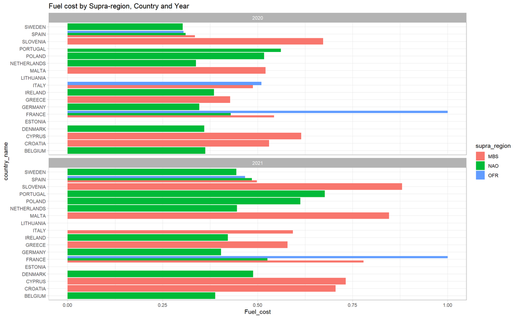

```r
AER_wide <- AER %>%
  dplyr::group_by(country_name, supra_region, gear_type, year, vessel_length, variable_name) %>%
  dplyr::summarise(total_value = sum(value, na.rm = TRUE)) %>%
  pivot_wider(names_from  = variable_name,
              values_from = total_value)

Fuel_cost <- AER_wide %>%
  group_by(country_name,supra_region, gear_type, year) %>%
  summarise(Energy_cost_sum = sum(Energy_costs),
            Energy_consumption_sum = sum(Energy_consumption)) %>%
  mutate(Fuel_cost = Energy_cost_sum / Energy_consumption_sum)


ggplot()+
  geom_bar(data = Fuel_cost, aes(x = Fuel_cost, y = country_name, fill = supra_region), stat = "identity", position = "dodge")+
  facet_wrap(~ year, nrow = 2)+
  theme_light()+
  ggtitle("Fuel cost by Supra-region, Country and Year")
```

Selects only the country and supra-region of interest and adds fuel cost data. Merges spatial fishing effort with economic variables for matching: year, vessel length, gear type, supra-region.

### Join AER - FDI

```r
AER_wide = AER_wide %>% filter(country_name %in% Country_CS, supra_region %in% supra_reg_CS)

AER_wide = AER_wide %>% left_join(Fuel_cost)


join_vars <- c("year","vessel_length", "gear_type", "supra_region")

aer_fdi <- FDI_effort %>%
  inner_join(AER_wide, by = join_vars)
```

### Redistribute economic variables

Computes the total fishing days for each economic grouping. Distributes each economic variable across c-squares proportionally to fishing effort (fishing days) in each cell.

```r
totals_days <- aer_fdi %>%
  group_by(across(all_of(join_vars))) %>%
  summarise(sum_days = sum(totfishdays, na.rm = TRUE))

# Add total effort to data
aer_fdi <- aer_fdi %>%
  left_join(totals_days, by = join_vars)

# Disaggregate GVA and Gross Profit proportionally to effort
aer_fdi_disagg <- aer_fdi %>%
  mutate(
    effort_share = ifelse(sum_days > 0,
                          totfishdays / sum_days,
                          0),
    GVL_disagg  = Gross_value_of_landings * effort_share,
    Other_income_disagg = Other_income * effort_share,
    Repair_maintenance_costs_disagg = Repair_maintenance_costs*effort_share,
    Other_variable_costs_disagg = Other_variable_costs * effort_share,
    Other_non_variable_costs_disagg = Other_non_variable_costs * effort_share,
    Personnel_costs_disagg =  Personnel_costs * effort_share,
    Value_of_unpaid_labour_disagg = Value_of_unpaid_labour * effort_share) %>%
  select(all_of(join_vars), GVL_disagg, Other_income_disagg, Repair_maintenance_costs_disagg,
         Other_variable_costs_disagg, Other_non_variable_costs_disagg, Personnel_costs_disagg, Value_of_unpaid_labour_disagg,
         cscode, gear_type, totfishdays, Fuel_cost)
```

### Applying Sala et al. fuel consumption model

Defines the parameters of the Sala model: Table 8 Sala et al., 2022 dFC = m × LOA + q → daily fuel consumption as a function of vessel length. (https://www.nature.com/articles/s41597-022-01478-0)

```r
Fuel_coefficients = data.frame(gear_type = c("OTB"),
                               m = c(1.470),
                               q = c(12.811))
```

Adds the fuel model parameters and assigns an average LOA to length classes. If you have VMS data and MMSI you can have more detailed LOA info

```r
x = aer_fdi_disagg
x = left_join(x, Fuel_coefficients, relationship = "many-to-many")

x = x %>% mutate(loa = recode(vessel_length,
                              "VL1824" = 21,
                              "VL1218" = 15,
                              "VL2440" = 32,
                              "VL0612" = 9))
```

Computes:

- daily fuel consumption = dFC = m ⋅ LOA + q
- annual consumption = FC = dFC * Total Fishing days (L/year)
- annual energy cost per cell = FC * fuel cost

```r
x$loaFC = x$q + (x$loa*x$m)
x$yFC = x$loaFC * x$totfishdays
x$EC = x$yFC * x$Fuel_cost
```

### Compute spatial GVA and Gross Profits

Re-computes GVA and Gross Profit after including the Sala-based energy costs.

- GVA = GVL + Other_income - EC - Repair_maintenance_costs - Other_variable_costs - Other_non_variable_costs;
- Gross_profit = GVL + Other_income - Personnel_costs - Value_of_unpaid_labour - EC - Repair_maintenance_costs - Other_variable_costs - Other_non_variable_costs

```r
x =   x %>%
  mutate(
    GVA = GVL_disagg + Other_income_disagg -
      EC - Repair_maintenance_costs_disagg -
      Other_variable_costs_disagg - Other_non_variable_costs_disagg,

    Gross_profit = GVL_disagg + Other_income_disagg -
      Personnel_costs_disagg - Value_of_unpaid_labour_disagg -
      EC - Repair_maintenance_costs_disagg -
      Other_variable_costs_disagg - Other_non_variable_costs_disagg)
```

Three maps are generated for:

- Energy Cost (EC)
- Gross Value Added (GVA)
- Gross Profit

Each map uses a similar structure:

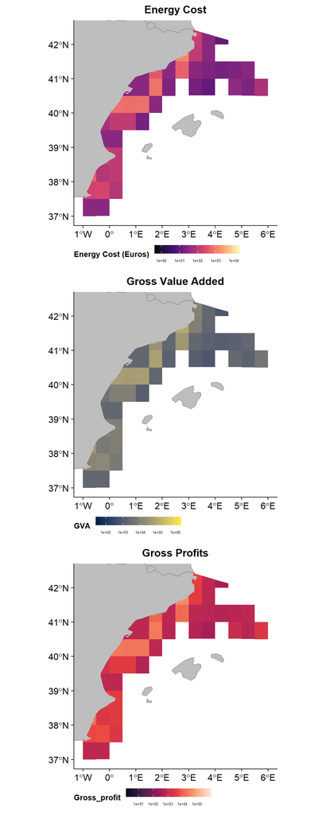

```r
g1 = x %>%
  inner_join(csquare) %>%
  st_as_sf %>%
  ggplot() +
  geom_sf(data = world, fill = "grey") +
  geom_sf(aes(fill = EC), colour = NA, inherit.aes = TRUE) +
  scale_fill_viridis_c("Energy Cost (Euros)", option = "magma",
                       trans = "log10", na.value = NA) +
  theme_cowplot() +
  theme(plot.title = element_text(size = 14, face = "bold", hjust = 0.5),
        legend.position = "bottom",
        legend.key.width = unit(0.8, "cm"),
        legend.key.height = unit(0.4, "cm"),
        legend.title = element_text(size = 10, face = "bold"),
        legend.text = element_text(size = 5),
        legend.box.margin = margin(t = 5, b = 5),
        legend.box.spacing = unit(0.1, "cm"))+
  scale_x_continuous(limits = c(xmin,xmax)) +
  scale_y_continuous(limits = c(ymin,ymax))+
  ggtitle("Energy Cost")

g2 = x %>%
  inner_join(csquare) %>%
  st_as_sf %>%
  ggplot() +
  geom_sf(data = world, fill = "grey") +
  geom_sf(aes(fill = GVA), colour = NA, inherit.aes = TRUE) +
  scale_fill_viridis_c("GVA", option = "cividis",
                       trans = "log10", na.value = NA) +
  theme_cowplot() +
  theme(plot.title = element_text(size = 14, face = "bold", hjust = 0.5),
        legend.position = "bottom",
        legend.key.width = unit(0.8, "cm"),
        legend.key.height = unit(0.4, "cm"),
        legend.title = element_text(size = 10, face = "bold"),
        legend.text = element_text(size = 5),
        legend.box.margin = margin(t = 5, b = 5),
        legend.box.spacing = unit(0.1, "cm"))+
  scale_x_continuous(limits = c(xmin,xmax)) +
  scale_y_continuous(limits = c(ymin,ymax))+
  ggtitle("Gross Value Added")


g3 = x %>%
  inner_join(csquare) %>%
  st_as_sf %>%
  ggplot() +
  geom_sf(data = world, fill = "grey") +
  geom_sf(aes(fill = Gross_profit), colour = NA, inherit.aes = TRUE) +
  scale_fill_viridis_c("Gross_profit", option = "rocket",
                       trans = "log10", na.value = NA) +
  theme_cowplot() +
  theme(plot.title = element_text(size = 14, face = "bold", hjust = 0.5),
        legend.position = "bottom",
        legend.key.width = unit(0.8, "cm"),
        legend.key.height = unit(0.4, "cm"),
        legend.title = element_text(size = 10, face = "bold"),
        legend.text = element_text(size = 5),
        legend.box.margin = margin(t = 5, b = 5),
        legend.box.spacing = unit(0.1, "cm"))+
  scale_x_continuous(limits = c(xmin,xmax)) +
  scale_y_continuous(limits = c(ymin,ymax))+
  ggtitle("Gross Profits")

gridExtra::grid.arrange(g1,g2,g3, nrow = 3)
```

Exports a final dataset including:

- disaggregated economic variables per c-square
- energy costs from the Sala model
- recalculated GVA and Gross Profit

```r
write.csv(x,
          "Spatial_Enegy_Cost.csv",
          row.names = FALSE)
```